# A fancy report

# Parent Doc

This is a report about fancy penguins.

If the condition is met we can add in our specific child document.

```r
day_of_week <- lubridate::ymd(Sys.Date()) %>%
  wday(label= TRUE) %>%
  as.character()
day_of_week
```

```
## [1] "Mon"
```

# Use of Child report

### Adelie Penguin Report

The Adélie penguin (Pygoscelis adeliae) is a species of penguin common along the entire coast of the Antarctic continent, which is its only habitat. It is the most widely spread penguin species, as well as the most southerly distributed of all penguins, along with the emperor penguin. It is named after Adélie Land, in turn named for Adèle Dumont d’Urville, who was married to French explorer Jules Dumont d’Urville, who first discovered, this penguin in 1840. Adélie penguins obtain their food by both predation and foraging with a diet of mainly krill and fish.

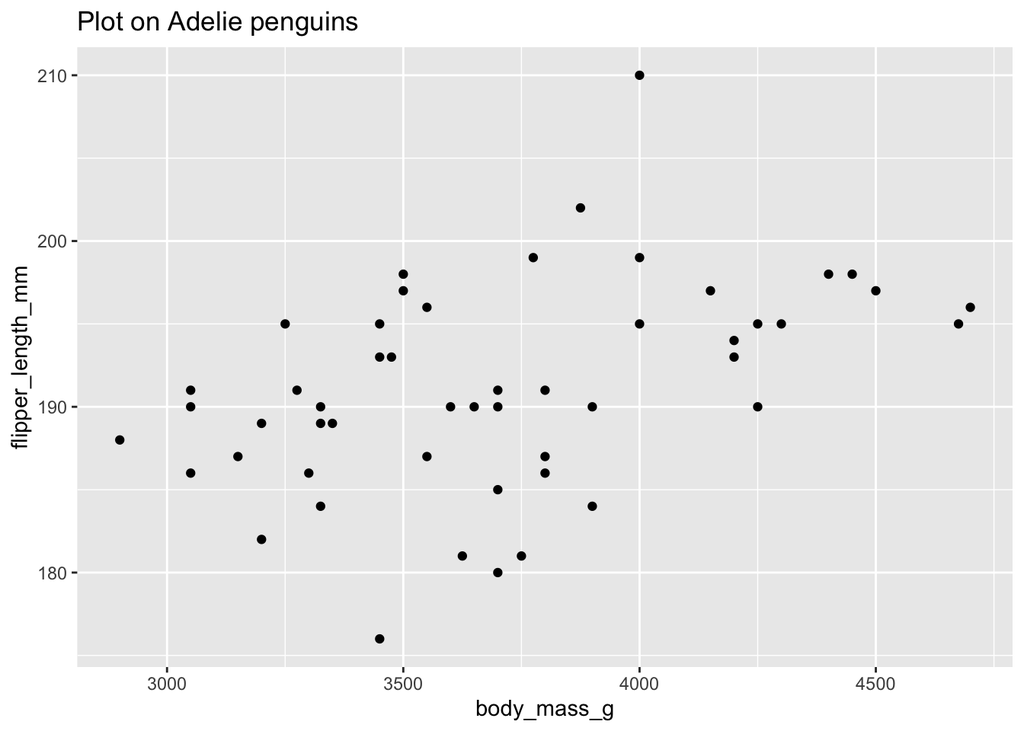

### Table alternative

Summary Table on Adelie penguins

| sex | bill_length_mm | bill_depth_mm | flipper_length_mm | body_mass_g |
| --- | --- | --- | --- | --- |
| female | 37.55 | 17.55 | 188.3 | 3396 |
| male | 40.59 | 19.39 | 194.9 | 4035 |

# Alternate with use of `results='asis'`

This option just used to generate some of the text inline, as opposed to all the plots/etc.

### Adelie Penguin Report

The Adélie penguin (Pygoscelis adeliae) is a species of penguin common along the entire coast of the Antarctic continent, which is its only habitat. It is the most widely spread penguin species, as well as the most southerly distributed of all penguins, along with the emperor penguin. It is named after Adélie Land, in turn named for Adèle Dumont d’Urville, who was married to French explorer Jules Dumont d’Urville, who first discovered, this penguin in 1840. Adélie penguins obtain their food by both predation and foraging with a diet of mainly krill and fish.

# Alternate with use of `whisker`

This fills a RMD and then writes out the components.

### `Adelie Penguin Report`

The Adélie penguin (Pygoscelis adeliae) is a species of penguin common along the entire coast of the Antarctic continent, which is its only habitat. It is the most widely spread penguin species, as well as the most southerly distributed of all penguins, along with the emperor penguin. It is named after Adélie Land, in turn named for Adèle Dumont d’Urville, who was married to French explorer Jules Dumont d’Urville, who first discovered, this penguin in 1840. Adélie penguins obtain their food by both predation and foraging with a diet of mainly krill and fish.

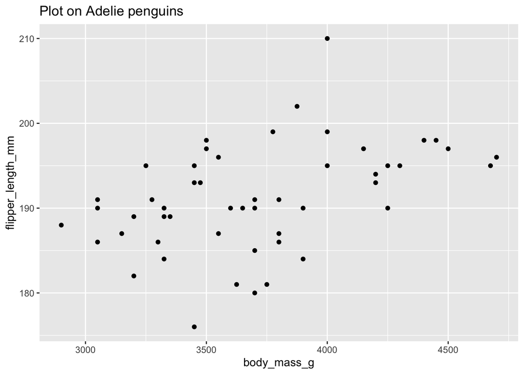

### Table alternative

Summary Table on Adelie penguins

| sex | bill_length_mm | bill_depth_mm | flipper_length_mm | body_mass_g |
| --- | --- | --- | --- | --- |
| female | 37.55 | 17.55 | 188.3 | 3396 |
| male | 40.59 | 19.39 | 194.9 | 4035 |